# Factorial Experiment Visualization (v2)

Author

Anthony Stewart

Published

July 19, 2026

Walkthrough of the v2 factorial experiment results (8 configs x 5 seeds x {multiclass, binary}) plus the follow-on studies (patch-count learning curve, UNet3+ comparison). Inputs are the small CSV/JSON aggregation outputs only:

- `dl_08_aggregate_factorial.py` -> `Models/factorial_results_v2/<mode>/analysis/`
- `dl_08b_aggregate_patchcurve.py` -> `Models/results_patchcurve_v2/<mode>/analysis/` and `Models/results_arch_v2/<mode>/analysis/`
- `dl_09b_shap_geomorph_export.py` -> `Models/factorial_results_v2/<mode>/analysis/shap_geomorph_channels.csv`

```r
library(tidyverse)
library(patchwork)
library(jsonlite)
library(colorspace)
library(scales)
```

```r
multi_dir  <- "../Models/factorial_results_v2/multiclass"
binary_dir <- "../Models/factorial_results_v2/binary"

multi_fact_data <- read.csv(file.path(multi_dir, "analysis/factorial_long.csv"))
glimpse(multi_fact_data)
```

```
Rows: 160
Columns: 19
$ config           <chr> "fld_nolidar_leafon", "fld_nolidar_leafon", "fld_noli…
$ label            <chr> "fld", "fld", "fld", "fld", "fld", "fld", "fld", "fld…
$ lidar            <chr> "nolidar", "nolidar", "nolidar", "nolidar", "nolidar"…
$ spectral         <chr> "leafon", "leafon", "leafon", "leafon", "leafon", "le…
$ featureset       <chr> "nolidar_leafon", "nolidar_leafon", "nolidar_leafon",…
$ seed             <int> 0, 0, 0, 0, 1, 1, 1, 1, 2, 2, 2, 2, 3, 3, 3, 3, 4, 4,…
$ macro_f1         <dbl> 0.5581, 0.5581, 0.5581, 0.5581, 0.5684, 0.5684, 0.568…
$ macro_recall     <dbl> 0.557725, 0.557725, 0.557725, 0.557725, 0.590225, 0.5…
$ macro_precision  <dbl> 0.585025, 0.585025, 0.585025, 0.585025, 0.570475, 0.5…
$ mean_iou         <dbl> 0.4161, 0.4161, 0.4161, 0.4161, 0.4264, 0.4264, 0.426…
$ overall_accuracy <dbl> 0.7092, 0.7092, 0.7092, 0.7092, 0.7016, 0.7016, 0.701…
$ in_channels      <int> 18, 18, 18, 18, 18, 18, 18, 18, 18, 18, 18, 18, 18, 1…
$ git_commit       <chr> "unknown", "unknown", "unknown", "unknown", "unknown"…
$ class            <chr> "EMW", "FSW", "SSW", "UPL", "EMW", "FSW", "SSW", "UPL…
$ precision        <dbl> 0.4103, 0.5948, 0.5112, 0.8238, 0.3756, 0.6441, 0.380…
$ recall           <dbl> 0.3591, 0.7667, 0.2611, 0.8440, 0.2353, 0.7764, 0.584…
$ f1               <dbl> 0.3830, 0.6699, 0.3457, 0.8337, 0.2893, 0.7041, 0.461…
$ iou              <dbl> 0.2369, 0.5037, 0.2090, 0.7149, 0.1691, 0.5433, 0.299…
$ support          <int> 621544, 966100, 566727, 3088482, 532418, 1459626, 662…
```

```r
binary_fact_data <- read.csv(file.path(binary_dir, "analysis/factorial_long.csv"))
glimpse(binary_fact_data)
```

```
Rows: 80
Columns: 19
$ config           <chr> "fld_nolidar_leafon", "fld_nolidar_leafon", "fld_noli…
$ label            <chr> "fld", "fld", "fld", "fld", "fld", "fld", "fld", "fld…
$ lidar            <chr> "nolidar", "nolidar", "nolidar", "nolidar", "nolidar"…
$ spectral         <chr> "leafon", "leafon", "leafon", "leafon", "leafon", "le…
$ featureset       <chr> "nolidar_leafon", "nolidar_leafon", "nolidar_leafon",…
$ seed             <int> 0, 0, 1, 1, 2, 2, 3, 3, 4, 4, 0, 0, 1, 1, 2, 2, 3, 3,…
$ macro_f1         <dbl> 0.8519, 0.8519, 0.8507, 0.8507, 0.8241, 0.8241, 0.777…
$ macro_recall     <dbl> 0.85640, 0.85640, 0.85225, 0.85225, 0.83150, 0.83150,…
$ macro_precision  <dbl> 0.84945, 0.84945, 0.84960, 0.84960, 0.82440, 0.82440,…
$ mean_iou         <dbl> 0.7426, 0.7426, 0.7406, 0.7406, 0.7011, 0.7011, 0.650…
$ overall_accuracy <dbl> 0.8550, 0.8550, 0.8526, 0.8526, 0.8252, 0.8252, 0.837…
$ in_channels      <int> 18, 18, 18, 18, 18, 18, 18, 18, 18, 18, 22, 22, 22, 2…
$ git_commit       <chr> "unknown", "unknown", "unknown", "unknown", "unknown"…
$ class            <chr> "WET", "UPL", "WET", "UPL", "WET", "UPL", "WET", "UPL…
$ precision        <dbl> 0.7993, 0.8996, 0.8187, 0.8805, 0.7548, 0.8940, 0.750…
$ recall           <dbl> 0.8642, 0.8486, 0.8497, 0.8548, 0.8745, 0.7885, 0.591…
$ f1               <dbl> 0.8304, 0.8733, 0.8339, 0.8675, 0.8103, 0.8380, 0.661…
$ iou              <dbl> 0.7100, 0.7752, 0.7152, 0.7660, 0.6810, 0.7211, 0.493…
$ support          <int> 2154371, 3088482, 2654734, 3440085, 2545399, 3418375,…
```

```r
config_order <- c("fld_nolidar_leafon", "fld_nolidar_leafoff",  "fld_chmret_leafon", "fld_chmret_leafoff",
                 "nwi_chmret_leafoff", "nwiextra_chmret_leafoff", "nwifield_chmret_leafoff", "flddeg_chmret_leafoff")

config_label <- c("fld_nolidar_leafon" = "Baseline",
                  "fld_nolidar_leafoff" = "With\nLeaf-Off",
                  "fld_chmret_leafon" = "With\nLidar",
                  "fld_chmret_leafoff" = "Full\nModel",
                  "nwi_chmret_leafoff" = "NWI\nData",
                  "nwiextra_chmret_leafoff" = "NWI\nx2",
                  "nwifield_chmret_leafoff" = "NWI\n+\nField",
                  "flddeg_chmret_leafoff" = "Degraded\nField")

# single-line variant for heatmap y-axes (stacked labels overlap there)
config_label_1line <- gsub("\n ", ", ", config_label)

class_order <- c("EMW", "FSW", "SSW", "WET", "UPL")
class_color <- c("FSW" = "#81b14f", "SSW" = "#c4bd8b", "EMW" = "#8faab3", "UPL" = "#6a4836", "WET" = "#388C73")

metric_label <- c("precision" = "Precision", "recall" = "Recall", "f1" = "F1", "iou" = "IoU",
                  "macro_f1" = "Macro F1", "mean_iou" = "Mean IoU", "overall_accuracy" = "Overall accuracy")

organize <- function(df) {
  df |>
    mutate(config = factor(config, levels = config_order),
           class  = factor(class,  levels = class_order))
}
multi_fact_data  <- organize(multi_fact_data)
binary_fact_data <- organize(binary_fact_data)

# Both modes in one frame for faceted figures
fact_data <- bind_rows(
  multi_fact_data  |> mutate(mode = "Multiclass"),
  binary_fact_data |> mutate(mode = "Binary")
) |> mutate(mode = factor(mode, levels = c("Multiclass", "Binary")))

theme_param <- theme(
  text = element_text(size = 18),
  legend.position = 'right',
  legend.text = element_text(size = rel(0.70), hjust = 0.5),
  panel.background = element_blank(),
  panel.grid.major = element_line(colour = "grey50", linewidth = 0.2),
  axis.ticks = element_blank(),
  axis.text = element_text(size = rel(0.9)),
  axis.title = element_text(size = rel(1)),
  strip.background = element_blank(),
  strip.text = element_text(size = rel(0.9), face = "bold")
)

theme_heatmap <- theme_param + theme(panel.grid.major = element_blank())

# Boxplot + jittered seed points, shared across the metric figures
box_jitter <- function(point_size = 5) {
  list(
    geom_boxplot(outlier.shape = NA, position = position_dodge(width = 0.75)),
    geom_jitter(position = position_jitterdodge(jitter.width = 0.15, dodge.width = 0.75),
                size = point_size, shape = 21, colour = "grey15")
  )
}

# Single-hue sequential fill for the heatmaps (magnitude = light -> dark)
seq_fill <- function(...) {
  scale_fill_gradient(low = "#f2f7f5", high = "#14523f", na.value = "grey93", ...)
}
```

### Conceptual figure or matrix for the factorial experiment design

Structure

- Sized for a slide: 16:9, few elements, large type, plain language (no “ablation”)
- Two tables sharing one model: table A varies the inputs with the field labels held constant, table B varies the training labels with the full input set held constant. The orange `fld_chmret_leafoff` model is the single model both tables have in common
- Only the inputs that actually *vary* get columns. Terrain, geomorphon and leaf-on NAIP are in every model, so they are stated once in the subtitle instead of drawn as always-filled columns
- Built from `fact_data` itself (label / lidar / spectral / in_channels are columns of `factorial_long.csv`), so the figure cannot drift out of sync with what actually ran

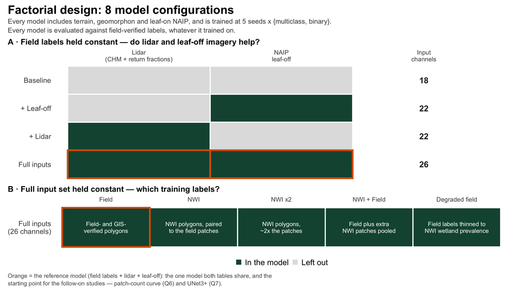

```r
reference <- "fld_chmret_leafoff"
ref_col   <- "#d95f02"

design_cells <- fact_data |>
  distinct(config, label, lidar, spectral, in_channels) |>
  mutate(config = as.character(config))

# ---- Table A: inputs vary, field labels held constant ------------------------
col_lidar    <- "Lidar\n(CHM + return fractions)"
col_leafoff  <- "NAIP\nleaf-off"
col_channels <- "Input\nchannels"
a_cols <- c(col_lidar, col_leafoff, col_channels)

a_row <- c("fld_nolidar_leafon"  = "Baseline",
           "fld_nolidar_leafoff" = "+ Leaf-off",
           "fld_chmret_leafon"   = "+ Lidar",
           "fld_chmret_leafoff"  = "Full inputs")

a_cells <- design_cells |>
  filter(label == "fld") |>
  mutate(config = factor(config, levels = rev(config_order)))

# "in"/"out" drive the fill; "meta" is the un-filled channel-count column
a_tiles <- bind_rows(
  a_cells |>
    mutate("{col_lidar}"   := if_else(lidar == "chmret", "in", "out"),
           "{col_leafoff}" := if_else(spectral == "leafoff", "in", "out")) |>
    pivot_longer(all_of(c(col_lidar, col_leafoff)), names_to = "input", values_to = "state"),
  a_cells |> mutate(input = col_channels, state = "meta")
) |>
  mutate(input = factor(input, levels = a_cols))

p_a <- ggplot(a_tiles, aes(x = input, y = config)) +
  geom_tile(aes(fill = state), colour = "white", linewidth = 1.2) +
  geom_tile(data = filter(a_tiles, config == reference, state != "meta"),
            fill = NA, colour = ref_col, linewidth = 1.8) +
  geom_text(data = filter(a_tiles, state == "meta"), aes(label = in_channels),
            colour = "grey15", size = 6.5, fontface = "bold") +
  scale_fill_manual(values = c("in" = "#14523f", "out" = "grey88", "meta" = "white"),
                    breaks = c("in", "out"), labels = c("In the model", "Left out"),
                    name = NULL, na.value = "white") +
  scale_x_discrete(limits = a_cols, position = "top") +
  scale_y_discrete(labels = a_row) +
  labs(x = NULL, y = NULL, title = "A · Field labels held constant — do lidar and leaf-off imagery help?")

# ---- Table B: training labels vary, full input set held constant --------------
b_head <- c("fld" = "Field", "nwi" = "NWI", "nwiextra" = "NWI x2",
            "nwifield" = "NWI + Field", "flddeg" = "Degraded field")

b_desc <- c("fld"      = "Field- and GIS-\nverified polygons",
            "nwi"      = "NWI polygons, paired\nto the field patches",
            "nwiextra" = "NWI polygons,\n~2x the patches",
            "nwifield" = "Field plus extra\nNWI patches pooled",
            "flddeg"   = "Field labels thinned to\nNWI wetland prevalence")

b_cells <- design_cells |>
  filter(lidar == "chmret", spectral == "leafoff") |>
  mutate(label = factor(label, levels = names(b_head)),
         row   = paste0("Full inputs\n(", in_channels, " channels)"))

p_b <- ggplot(b_cells, aes(x = label, y = row)) +
  geom_tile(fill = "#14523f", colour = "white", linewidth = 1.2) +
  geom_tile(data = filter(b_cells, config == reference),
            fill = NA, colour = ref_col, linewidth = 1.8) +
  geom_text(aes(label = b_desc[as.character(label)]),
            colour = "white", size = 4.6, lineheight = 0.95) +
  scale_x_discrete(labels = b_head, position = "top") +
  labs(x = NULL, y = NULL, title = "B · Full input set held constant — which training labels?")

n_seeds <- n_distinct(fact_data$seed)

theme_design <- theme_heatmap +
  theme(text = element_text(size = 22),
        legend.position = "bottom",
        legend.text = element_text(size = rel(0.8), hjust = 0),
        axis.text.x = element_text(size = rel(0.7), lineheight = 0.9),
        axis.text.y = element_text(size = rel(0.8), hjust = 1, lineheight = 0.9),
        plot.title = element_text(size = rel(0.8), face = "bold"),
        plot.title.position = "plot")

(p_a + theme_design) / (p_b + theme_design) +
  plot_layout(heights = c(4, 1.6), guides = "collect") +
  plot_annotation(
    title = "Factorial design: 8 model configurations",
    subtitle = paste0("Every model includes terrain, geomorphon and leaf-on NAIP, and is trained at ",
                      n_seeds, " seeds x {multiclass, binary}.\n",
                      "Every model is evaluated against field-verified labels, whatever it trained on."),
    caption = paste0("Orange = the reference model (field labels + lidar + leaf-off): the one model both ",
                     "tables share, and the\nstarting point for the follow-on studies — patch-count curve (Q6) ",
                     "and UNet3+ (Q7)."),
    theme = theme(plot.title = element_text(size = 26, face = "bold"),
                  plot.subtitle = element_text(size = 15, colour = "grey30", lineheight = 1.1),
                  plot.caption = element_text(size = 13, colour = "grey35", hjust = 0, lineheight = 1.1),
                  plot.title.position = "plot",
                  plot.caption.position = "plot",
                  legend.position = "bottom",
                  plot.margin = margin(12, 18, 12, 12))
  )
```

### Does leaf off imagery or lidar-derived metrics improve field-based models?

Structure

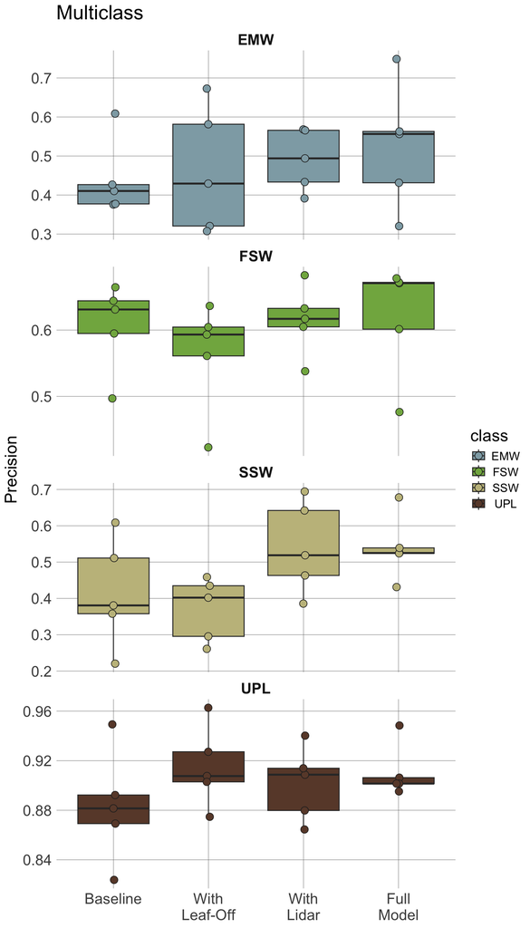

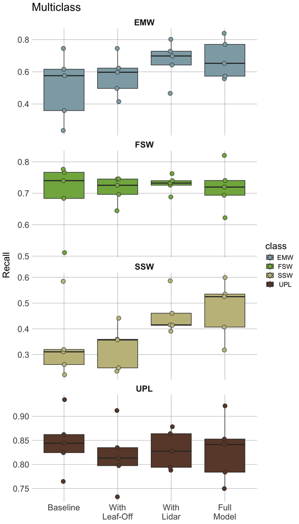

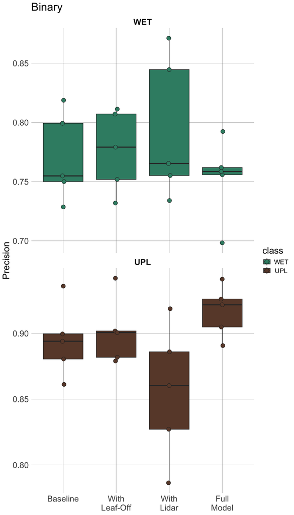

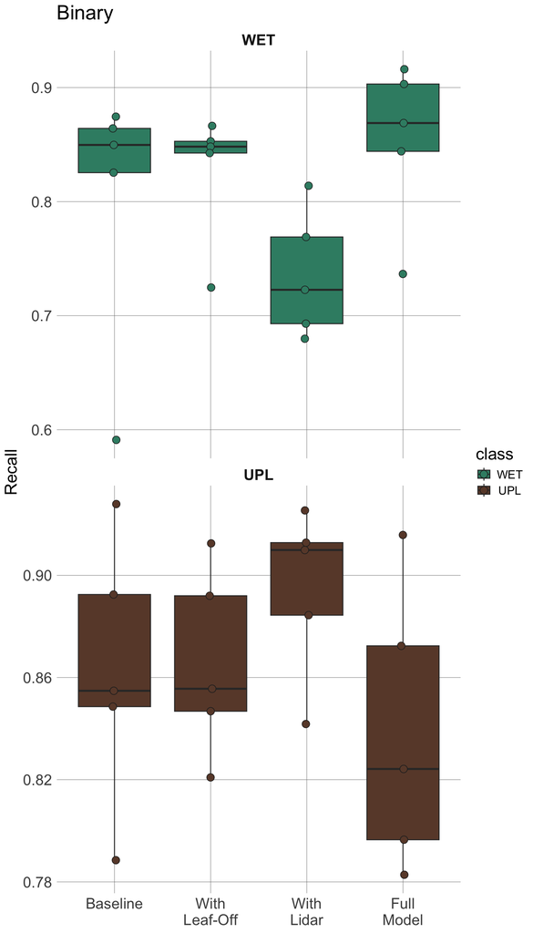

```r
pr_data <- fact_data |>
  filter(label == "fld") |>
  pivot_longer(c(precision, recall), names_to = "metric", values_to = "value") |>
  mutate(metric = factor(metric_label[metric], levels = c("Precision", "Recall")))

pr_plot <- function(which_mode, which_metric) {
  pr_data |>
    filter(mode == which_mode, metric == which_metric) |>
    ggplot(aes(x = config, y = value, fill = class)) +
      facet_wrap(~ class, scales = "free_y", ncol = 1) +
      box_jitter(point_size = 3.5) +
      scale_fill_manual(values = class_color) +
      scale_x_discrete(labels = config_label) +
      labs(x = NULL, y = which_metric, title = which_mode) +
      theme_param
}

pr_plot("Multiclass", "Precision")
pr_plot("Multiclass", "Recall")
pr_plot("Binary", "Precision")
pr_plot("Binary", "Recall")
```

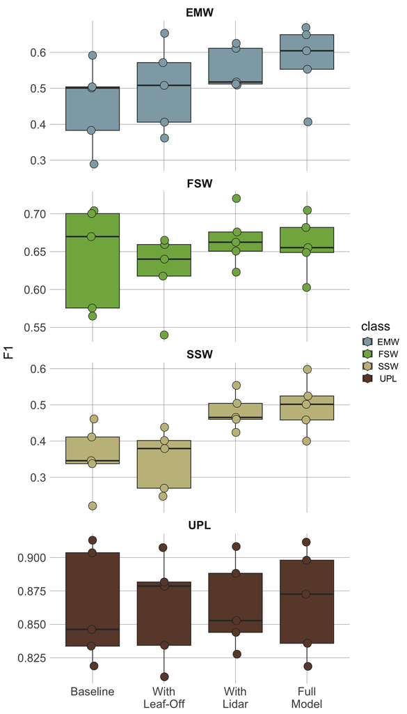

```r
fact_data |>
  filter(label == "fld", mode == "Multiclass") |>
  ggplot(aes(x = config, y = f1, fill = class)) +
    box_jitter() +
    facet_wrap(~ class, scales = "free_y", ncol = 1) +
    scale_fill_manual(values = class_color) +
    scale_x_discrete(labels = config_label) +
    labs(x = NULL, y = "F1") +
    theme_param
```

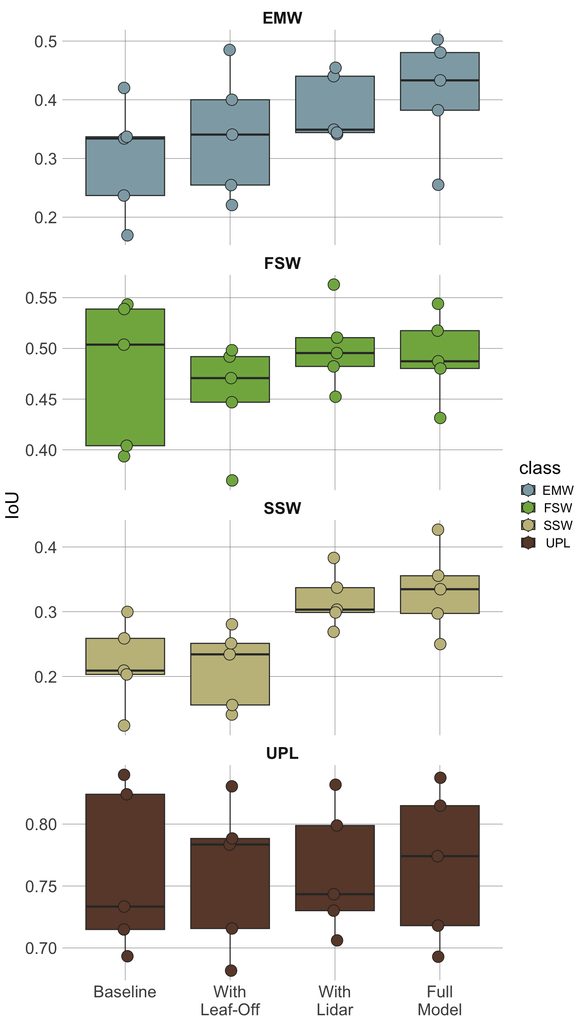

```r
fact_data |>
  filter(label == "fld", mode == "Multiclass") |>
  ggplot(aes(x = config, y = iou, fill = class)) +
    box_jitter() +
    facet_wrap(~ class, scales = "free_y", ncol = 1) +
    scale_fill_manual(values = class_color) +
    scale_x_discrete(labels = config_label) +
    labs(x = NULL, y = "IoU") +
    theme_param
```

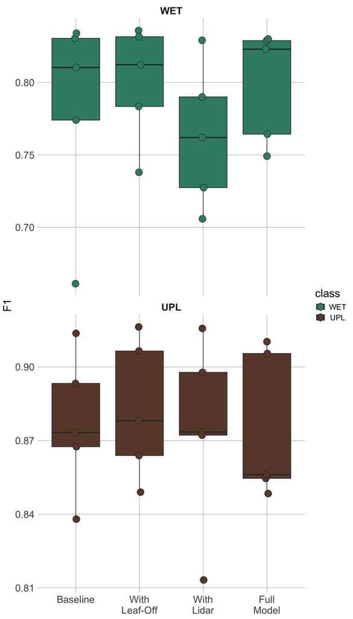

```r
  fact_data |>
  filter(label == "fld", mode == "Binary") |>
  ggplot(aes(x = config, y = f1, fill = class)) +
    box_jitter() +
    facet_wrap(~ class, scales = "free_y", ncol = 1) +
    scale_fill_manual(values = class_color) +
    scale_x_discrete(labels = config_label) +
    labs(x = NULL, y = "F1") +
    theme_param
```

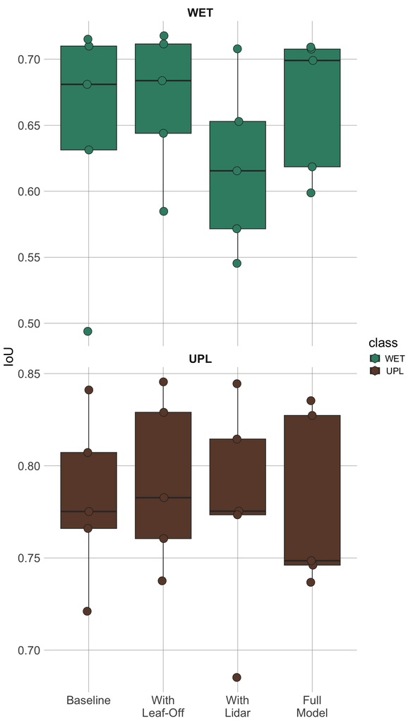

```r
fact_data |>
  filter(label == "fld", mode == "Binary") |>
  ggplot(aes(x = config, y = iou, fill = class)) +
    box_jitter() +
    facet_wrap(~ class, scales = "free_y", ncol = 1) +
    scale_fill_manual(values = class_color) +
    scale_x_discrete(labels = config_label) +
    labs(x = NULL, y = "IoU") +
    theme_param
```

### How do NWI data labels compare to field and GIS-derived data?

#### Also does degrading the field data hinder its performance?

- All label sources on the full feature set (`chmret_leafoff`), evaluated against field labels

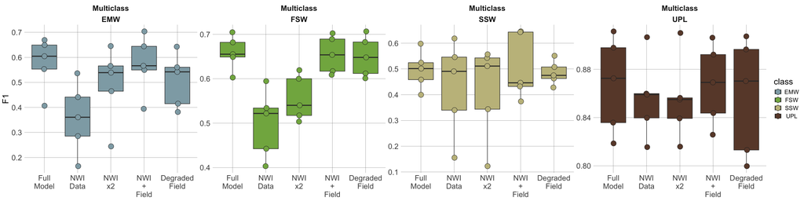

```r
fact_data |>
  filter(featureset == "chmret_leafoff", mode == "Multiclass") |>
  ggplot(aes(x = config, y = f1, fill = class)) +
    box_jitter() +
    facet_wrap(mode ~ class, scales = "free_y", ncol = 4) +
    scale_fill_manual(values = class_color) +
    scale_x_discrete(labels = config_label) +
    labs(x = NULL, y = "F1") +
    theme_param
```

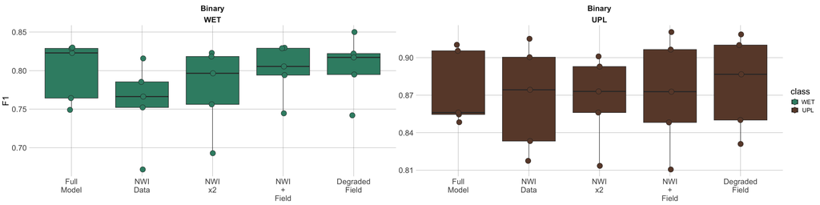

```r
fact_data |>
  filter(featureset == "chmret_leafoff", mode == "Binary") |>
  ggplot(aes(x = config, y = f1, fill = class)) +
    box_jitter() +
    facet_wrap(mode ~ class, scales = "free_y", ncol = 4) +
    scale_fill_manual(values = class_color) +
    scale_x_discrete(labels = config_label) +
    labs(x = NULL, y = "F1") +
    theme_param
```

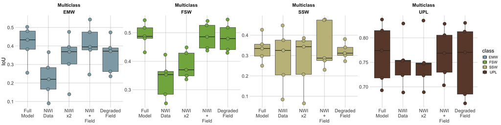

```r
fact_data |>
  filter(featureset == "chmret_leafoff", mode == "Multiclass") |>
  ggplot(aes(x = config, y = iou, fill = class)) +
    box_jitter() +
    facet_wrap(mode ~ class, scales = "free_y", ncol = 4) +
    scale_fill_manual(values = class_color) +
    scale_x_discrete(labels = config_label) +
    labs(x = NULL, y = "IoU") +
    theme_param
```

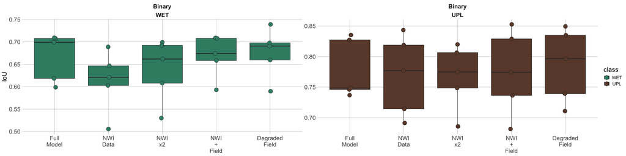

```r
fact_data |>
  filter(featureset == "chmret_leafoff", mode == "Binary") |>
  ggplot(aes(x = config, y = iou, fill = class)) +
    box_jitter() +
    facet_wrap(mode ~ class, scales = "free_y", ncol = 4) +
    scale_fill_manual(values = class_color) +
    scale_x_discrete(labels = config_label) +
    labs(x = NULL, y = "IoU") +
    theme_param
```

Model-level summary (macro metrics are repeated on every class row of `factorial_long.csv`, so collapse to one row per model first):

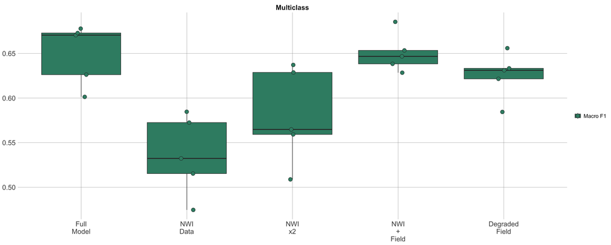

```r
fact_data |>
  filter(featureset == "chmret_leafoff", mode == "Multiclass") |>
  distinct(mode, config, seed, macro_f1) |>
  pivot_longer(c(macro_f1), names_to = "metric", values_to = "value") |>
  mutate(metric = metric_label[metric]) |>
  ggplot(aes(x = config, y = value, fill = metric)) +
    box_jitter(point_size = 4) +
    facet_grid(. ~ mode) +
    scale_fill_manual(values = c("Macro F1" = "#388C73", "Mean IoU" = lighten("#388C73", 0.45)), name = NULL) +
    scale_x_discrete(labels = config_label) +
    labs(x = NULL, y = NULL) +
    theme_param
```

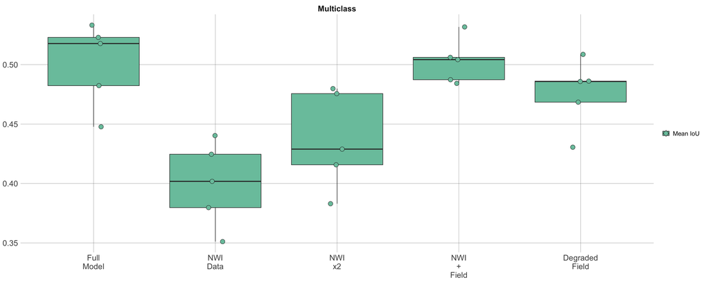

```r
fact_data |>
  filter(featureset == "chmret_leafoff", mode == "Multiclass") |>
  distinct(mode, config, seed, mean_iou) |>
  pivot_longer(c(mean_iou), names_to = "metric", values_to = "value") |>
  mutate(metric = metric_label[metric]) |>
  ggplot(aes(x = config, y = value, fill = metric)) +
    box_jitter(point_size = 4) +
    facet_grid(. ~ mode) +
    scale_fill_manual(values = c("Macro F1" = "#388C73", "Mean IoU" = lighten("#388C73", 0.45)), name = NULL) +
    scale_x_discrete(labels = config_label) +
    labs(x = NULL, y = NULL) +
    theme_param
```

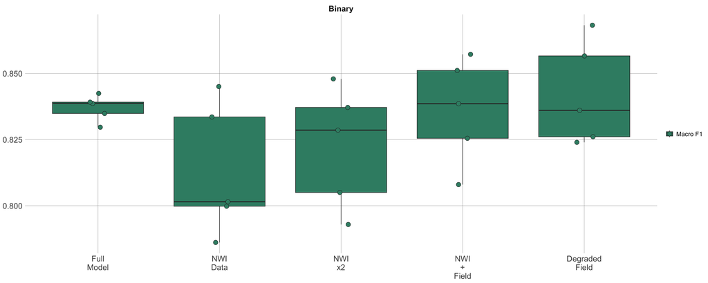

```r
fact_data |>
  filter(featureset == "chmret_leafoff", mode == "Binary") |>
  distinct(mode, config, seed, macro_f1) |>
  pivot_longer(c(macro_f1), names_to = "metric", values_to = "value") |>
  mutate(metric = metric_label[metric]) |>
  ggplot(aes(x = config, y = value, fill = metric)) +
    box_jitter(point_size = 4) +
    facet_grid(. ~ mode) +
    scale_fill_manual(values = c("Macro F1" = "#388C73", "Mean IoU" = lighten("#388C73", 0.45)), name = NULL) +
    scale_x_discrete(labels = config_label) +
    labs(x = NULL, y = NULL) +
    theme_param
```

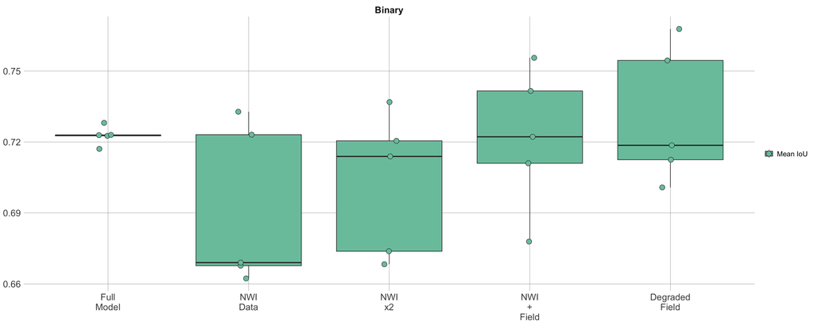

```r
fact_data |>
  filter(featureset == "chmret_leafoff", mode == "Binary") |>
  distinct(mode, config, seed, mean_iou) |>
  pivot_longer(c(mean_iou), names_to = "metric", values_to = "value") |>
  mutate(metric = metric_label[metric]) |>
  ggplot(aes(x = config, y = value, fill = metric)) +
    box_jitter(point_size = 4) +
    facet_grid(. ~ mode) +
    scale_fill_manual(values = c("Macro F1" = "#388C73", "Mean IoU" = lighten("#388C73", 0.45)), name = NULL) +
    scale_x_discrete(labels = config_label) +
    labs(x = NULL, y = NULL) +
    theme_param
```

### How do field and NWI models compare across each other

- Heat maps of model metrics: config (rows) x class (cols), one panel per metric.

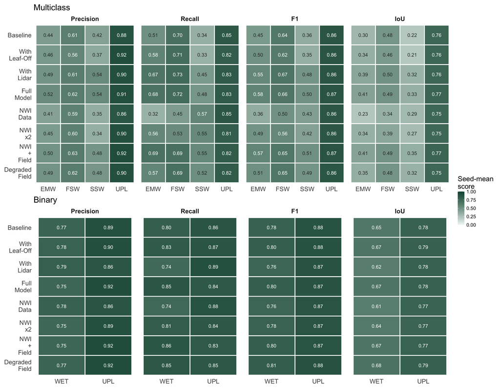

```r
metric_heat <- fact_data |>
  pivot_longer(c(precision, recall, f1, iou), names_to = "metric", values_to = "value") |>
  mutate(metric = factor(metric_label[metric], levels = c("Precision", "Recall", "F1", "IoU"))) |>
  group_by(mode, config, class, metric) |>
  summarise(value = mean(value), .groups = "drop")

heat_panel <- function(which_mode) {
  metric_heat |>
    filter(mode == which_mode) |>
    ggplot(aes(x = class, y = fct_rev(config), fill = value)) +
      geom_tile(colour = "white", linewidth = 1) +
      geom_text(aes(label = number(value, accuracy = 0.01),
                    colour = value > 0.55), size = 4.5, show.legend = FALSE) +
      facet_grid(. ~ metric) +
      scale_colour_manual(values = c(`TRUE` = "white", `FALSE` = "grey20")) +
      seq_fill(limits = c(0, 1), name = "Seed-mean\nscore") +
      scale_y_discrete(labels = config_label_1line) +
      labs(x = NULL, y = NULL, title = which_mode) +
      theme_heatmap
}

heat_panel("Multiclass") / heat_panel("Binary") +
  plot_layout(guides = "collect", heights = c(1, 1))
```

### How accurate are the classes via confusion matrices?

- binary and multiclass model confusion matrices for each configuration
- color and fill by relative % but include a parentheses with the number of pixels e.g. 70% (3,400,000)
- rows (true class) sum to 100%, so the diagonal reads as recall; counts are seed-mean pixels

```r
read_confusion <- function(mode_dir) {
  map_dfr(config_order, function(cfg) {
    f <- file.path(mode_dir, "analysis/confusion_mean", paste0(cfg, ".csv"))
    if (!file.exists(f)) return(NULL)
    read.csv(f, row.names = 1, check.names = FALSE) |>
      rownames_to_column("true") |>
      pivot_longer(-true, names_to = "pred", values_to = "n") |>
      mutate(config = factor(cfg, levels = config_order))
  }) |>
    group_by(config, true) |>
    mutate(prop = n / sum(n)) |>
    ungroup() |>
    mutate(true = factor(true, levels = rev(class_order)),
           pred = factor(pred, levels = class_order),
           cell_label = paste0(percent(prop, accuracy = 1), "\n(",
                               number(n, accuracy = 0.1, scale_cut = cut_short_scale()), ")"))
}

confusion_plot <- function(mode_dir, title, text_size = 4.5) {
  read_confusion(mode_dir) |>
    ggplot(aes(x = pred, y = true, fill = prop)) +
      geom_tile(colour = "white", linewidth = 1) +
      geom_text(aes(label = cell_label, colour = prop > 0.55),
                size = text_size, lineheight = 0.9, show.legend = FALSE) +
      facet_wrap(~ config, ncol = 4, labeller = labeller(config = config_label)) +
      scale_colour_manual(values = c(`TRUE` = "white", `FALSE` = "grey20")) +
      seq_fill(limits = c(0, 1), labels = percent, name = "% of\ntrue class") +
      labs(x = "Predicted", y = "True", title = title) +
      theme_heatmap
}
```

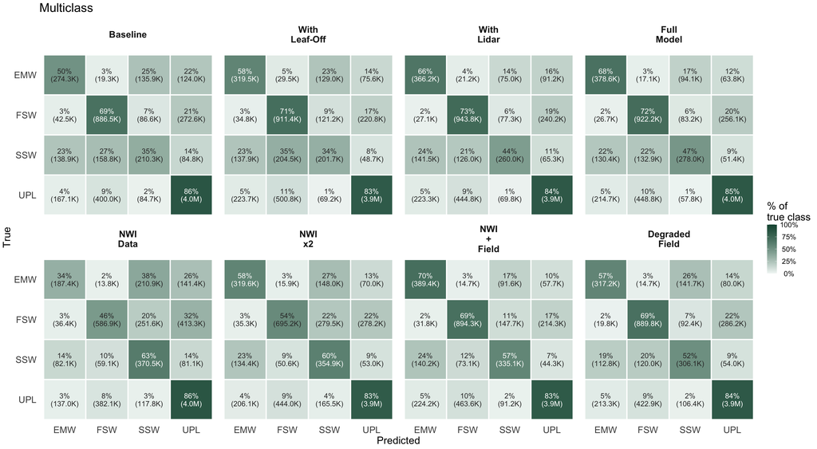

```r
confusion_plot(multi_dir, "Multiclass")
```

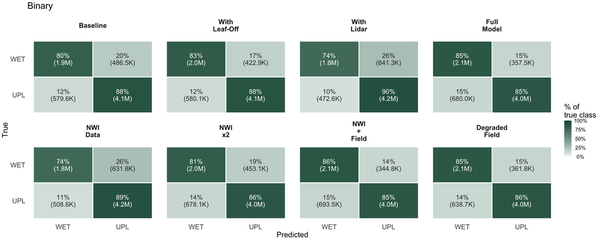

```r
confusion_plot(binary_dir, "Binary", text_size = 5.5)
```

### What were the important features in each model configuration according to SHAP?

- Model heatmap with cross-model comparison: each model normalized to its own total importance, so bands are comparable across configs. Bands a config doesn’t use are blank.
- Uses the PER-CHANNEL MEAN aggregation (not the raw sum) so the one-hot Geomorph_local band is not inflated 10x relative to single-channel bands.
- Also show within the Geomorphons category a heatmap of the different categories across models

```r
band_order <- c("DEM", "slope_local", "Geomorph_local", "flowacc", "twi",
                "CHM", "pct_below_1m", "pct_1m_to_5m", "pct_above_5m",
                "r", "g", "b", "nir", "r_lo", "g_lo", "b_lo", "nir_lo")

band_label <- c("DEM" = "DEM", "slope_local" = "Slope", "Geomorph_local" = "Geomorphons",
                "flowacc" = "Flow accum.", "twi" = "TWI",
                "CHM" = "CHM", "pct_below_1m" = "% returns < 1 m",
                "pct_1m_to_5m" = "% returns 1-5 m", "pct_above_5m" = "% returns > 5 m",
                "r" = "Red (leaf-on)", "g" = "Green (leaf-on)", "b" = "Blue (leaf-on)", "nir" = "NIR (leaf-on)",
                "r_lo" = "Red (leaf-off)", "g_lo" = "Green (leaf-off)", "b_lo" = "Blue (leaf-off)", "nir_lo" = "NIR (leaf-off)")

read_shap_mode <- function(mode_dir) {
  files <- Sys.glob(file.path(mode_dir, "*", "seed*", "shap", "*_shap_importance.json"))
  map_dfr(files, function(f) {
    j <- fromJSON(f)
    tibble(
      config = basename(dirname(dirname(dirname(f)))),
      seed   = parse_number(str_extract(f, "seed\\d+")),
      band   = names(j$importance_overall_per_channel),
      value  = unlist(j$importance_overall_per_channel)
    )
  })
}

shap_share <- bind_rows(
  read_shap_mode(multi_dir)  |> mutate(mode = "Multiclass"),
  read_shap_mode(binary_dir) |> mutate(mode = "Binary")
) |>
  group_by(mode, config, band) |>
  summarise(value = mean(value), .groups = "drop_last") |>   # mean over seeds
  mutate(share = value / sum(value)) |>                      # normalize per model
  ungroup() |>
  complete(mode, config = config_order, band = band_order) |>  # blanks for unused bands
  mutate(mode   = factor(mode, levels = c("Multiclass", "Binary")),
         config = factor(config, levels = config_order),
         band   = factor(band, levels = rev(band_order)))
```

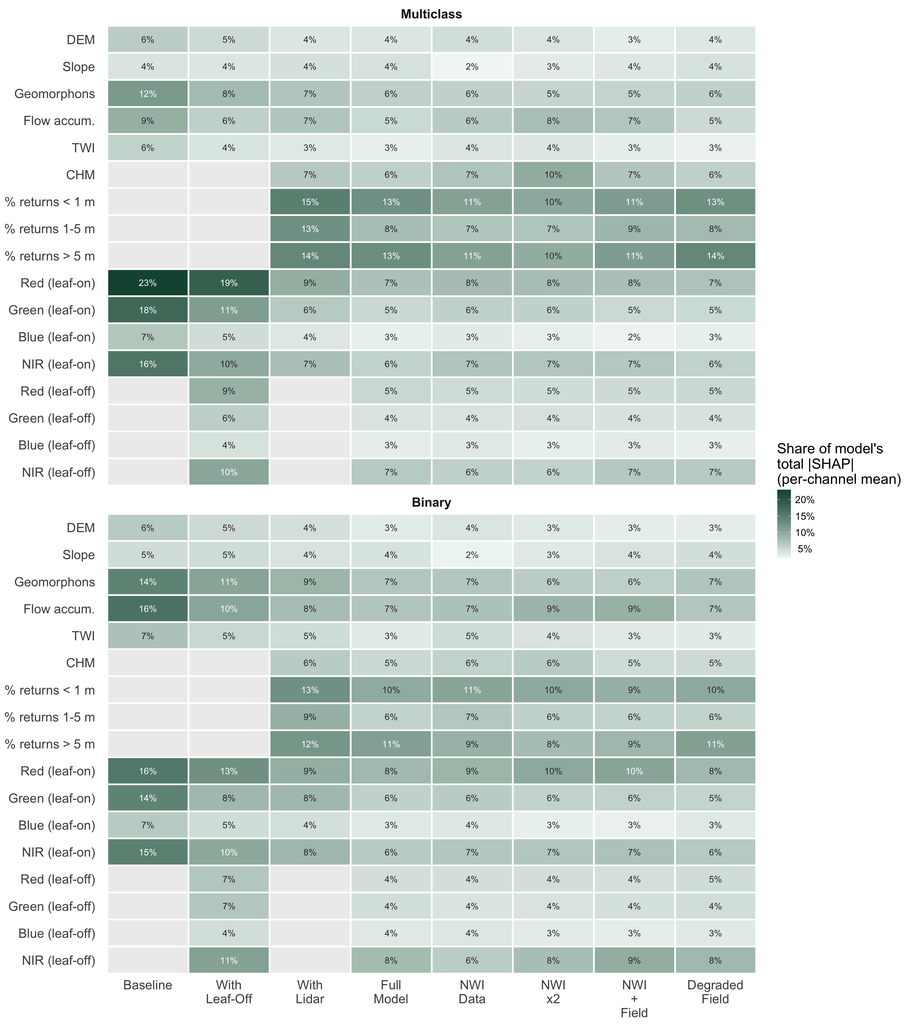

```r
shap_share |>
  ggplot(aes(x = config, y = band, fill = share)) +
    geom_tile(colour = "white", linewidth = 1) +
    geom_text(aes(label = percent(share, accuracy = 1), colour = share > 0.10),
              size = 4, na.rm = TRUE, show.legend = FALSE) +
    facet_wrap(~ mode, ncol = 1) +
    scale_colour_manual(values = c(`TRUE` = "white", `FALSE` = "grey20")) +
    seq_fill(labels = percent, name = "Share of model's\ntotal |SHAP|\n(per-channel mean)") +
    scale_x_discrete(labels = config_label) +
    scale_y_discrete(labels = band_label) +
    labs(x = NULL, y = NULL) +
    theme_heatmap
```

Within the Geomorphons band: which landform channels carry the importance (share of the band’s total, seed-mean; forms follow the `rgeomorphon`/GRASS value order 1-10):

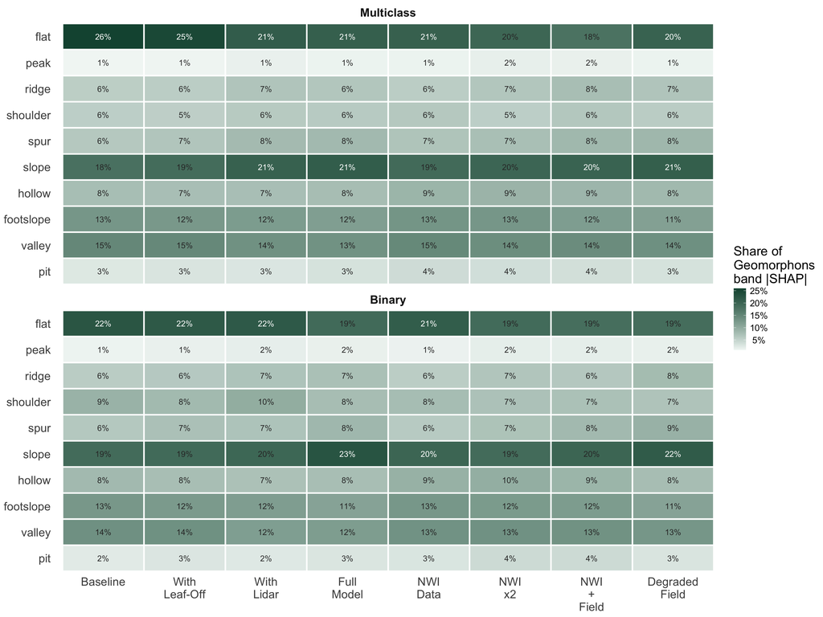

```r
geomorph_forms <- c("flat", "peak", "ridge", "shoulder", "spur",
                    "slope", "hollow", "footslope", "valley", "pit")

geomorph_shap <- bind_rows(
  read.csv(file.path(multi_dir,  "analysis/shap_geomorph_channels.csv")) |> mutate(mode = "Multiclass"),
  read.csv(file.path(binary_dir, "analysis/shap_geomorph_channels.csv")) |> mutate(mode = "Binary")
) |>
  filter(class == "overall") |>
  group_by(mode, config, geomorphon_form) |>
  summarise(value = mean(mean_abs_shap), .groups = "drop_last") |>
  mutate(share = value / sum(value)) |>
  ungroup() |>
  mutate(mode   = factor(mode, levels = c("Multiclass", "Binary")),
         config = factor(config, levels = config_order),
         geomorphon_form = factor(geomorphon_form, levels = rev(geomorph_forms)))

geomorph_shap |>
  ggplot(aes(x = config, y = geomorphon_form, fill = share)) +
    geom_tile(colour = "white", linewidth = 1) +
    geom_text(aes(label = percent(share, accuracy = 1), colour = share > 0.20),
              size = 4, show.legend = FALSE) +
    facet_wrap(~ mode, ncol = 1) +
    scale_colour_manual(values = c(`TRUE` = "white", `FALSE` = "grey20")) +
    seq_fill(labels = percent, name = "Share of\nGeomorphons\nband |SHAP|") +
    scale_x_discrete(labels = config_label) +
    labs(x = NULL, y = NULL) +
    theme_heatmap
```

### Does the number of patches matter for model accuracy

- F1, IoU, Precision, Recall graphs across the patch numbers input into the model
- Include binary and multiclass stacked graphs
- x-axis is the REALIZED training-set size (from `training_log.json`), points are seeds, lines are seed means
- The `n500` level is dropped: the field-anchored split leaves only ~440-510 training patches, so `n500` realizes essentially the same size as `full` and the two levels overlap.

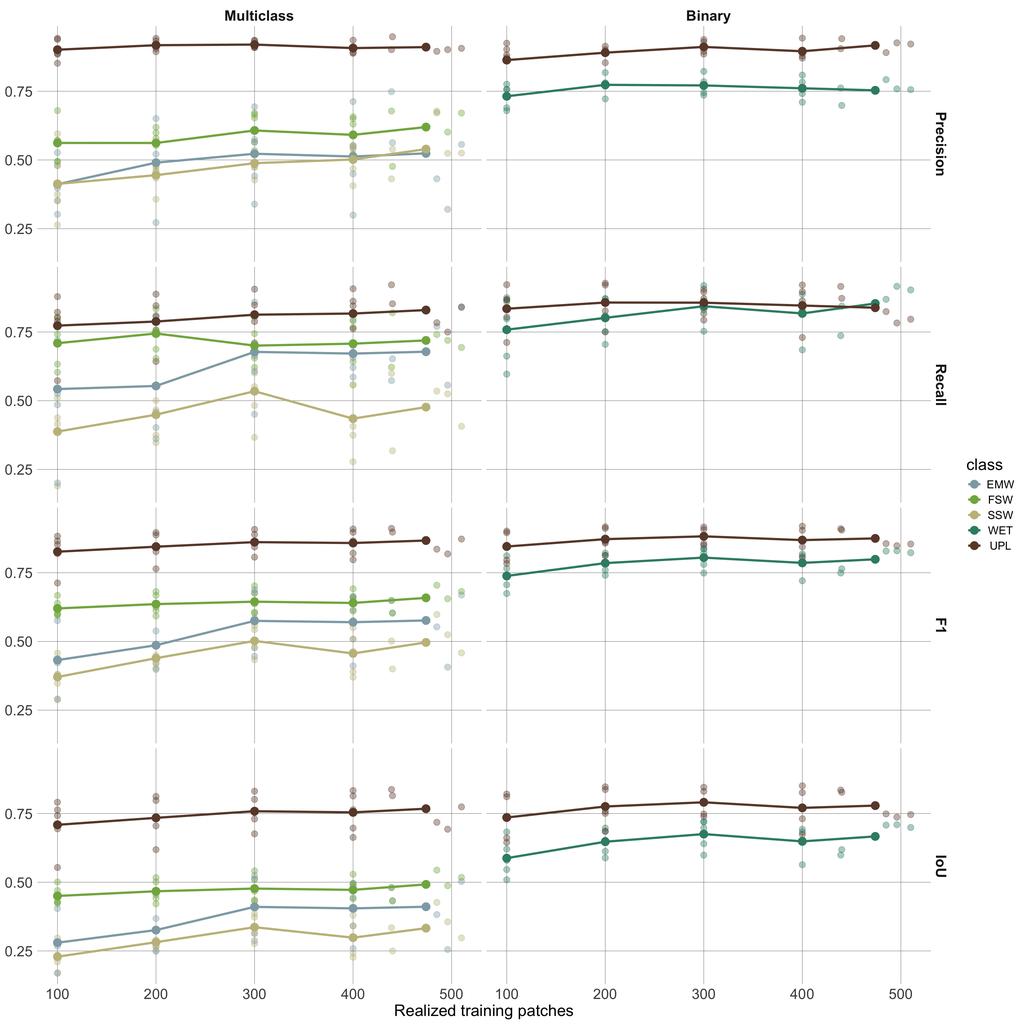

```r
patchcurve <- bind_rows(
  read.csv("../Models/results_patchcurve_v2/multiclass/analysis/patchcurve_long.csv") |> mutate(mode = "Multiclass"),
  read.csv("../Models/results_patchcurve_v2/binary/analysis/patchcurve_long.csv")     |> mutate(mode = "Binary")
) |>
  filter(level != "500") |>   # n500 == full given the ~440-510 patch pool cap
  mutate(mode = factor(mode, levels = c("Multiclass", "Binary")))

pc_class <- patchcurve |>
  pivot_longer(matches("^(iou|f1|precision|recall)_"),
               names_pattern = "^(iou|f1|precision|recall)_(.+)$",
               names_to = c("metric", "class"), values_to = "value") |>
  filter(!is.na(value)) |>   # bind_rows pads the other mode's class columns with NA
  mutate(metric = factor(metric_label[metric], levels = c("Precision", "Recall", "F1", "IoU")),
         class  = factor(class, levels = class_order))

# the realized train count varies a little across seeds within a level,
# so average x and y per level for the mean line
pc_class_mean <- pc_class |>
  group_by(mode, metric, class, level) |>
  summarise(train_patches = mean(train_patches), value = mean(value), .groups = "drop")

pc_class |>
  ggplot(aes(x = train_patches, y = value, colour = class)) +
    geom_point(size = 3, alpha = 0.4) +
    geom_line(data = pc_class_mean, linewidth = 1.2) +
    geom_point(data = pc_class_mean, size = 4) +
    facet_grid(metric ~ mode) +
    scale_colour_manual(values = class_color) +
    labs(x = "Realized training patches", y = NULL) +
    theme_param
```

Model-level curve (macro metrics):

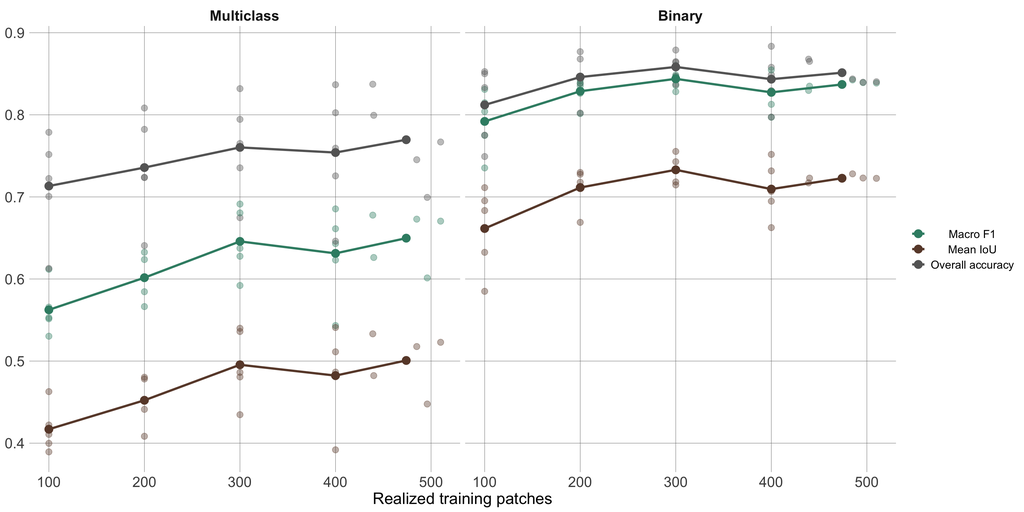

```r
pc_macro <- patchcurve |>
  pivot_longer(c(macro_f1, mean_iou, overall_accuracy), names_to = "metric", values_to = "value") |>
  mutate(metric = factor(metric_label[metric], levels = c("Macro F1", "Mean IoU", "Overall accuracy")))

pc_macro_mean <- pc_macro |>
  group_by(mode, metric, level) |>
  summarise(train_patches = mean(train_patches), value = mean(value), .groups = "drop")

pc_macro |>
  ggplot(aes(x = train_patches, y = value, colour = metric)) +
    geom_point(size = 3, alpha = 0.4) +
    geom_line(data = pc_macro_mean, linewidth = 1.2) +
    geom_point(data = pc_macro_mean, size = 4) +
    facet_grid(. ~ mode) +
    scale_colour_manual(values = c("Macro F1" = "#388C73", "Mean IoU" = "#6a4836",
                                   "Overall accuracy" = "grey40"), name = NULL) +
    labs(x = "Realized training patches", y = NULL) +
    theme_param
```

### Does model architecture matter?

- Boxplot of metrics with point overlaid to show distribution of model runs
- U-Net vs UNet3+ on `fld_chmret_leafoff` (same seeds -> same test patches; bf64/d5 held constant)

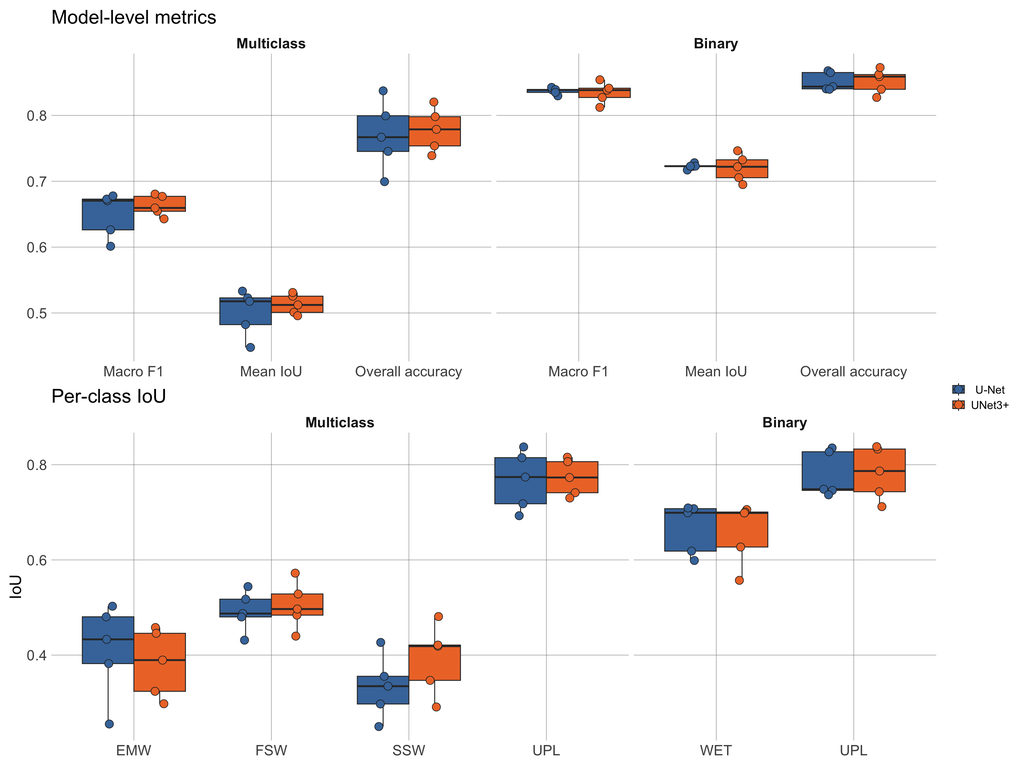

```r
arch_color <- c("U-Net" = "#4477AA", "UNet3+" = "#EE7733")

arch_data <- bind_rows(
  read.csv("../Models/results_arch_v2/multiclass/analysis/arch_compare.csv") |> mutate(mode = "Multiclass"),
  read.csv("../Models/results_arch_v2/binary/analysis/arch_compare.csv")     |> mutate(mode = "Binary")
) |>
  filter(seed != "mean") |>
  select(-starts_with("arch_"), -starts_with("delta_")) |>
  pivot_longer(-c(config, seed, mode),
               names_pattern = "^(.*)_(unet3plus|unet)$",
               names_to = c("metric", "arch"), values_to = "value") |>
  filter(!is.na(value)) |>   # bind_rows pads the other mode's class columns with NA
  mutate(mode = factor(mode, levels = c("Multiclass", "Binary")),
         arch = factor(if_else(arch == "unet", "U-Net", "UNet3+"), levels = names(arch_color)))

arch_macro <- arch_data |>
  filter(metric %in% names(metric_label)) |>
  mutate(metric = factor(metric_label[metric], levels = c("Macro F1", "Mean IoU", "Overall accuracy"))) |>
  ggplot(aes(x = metric, y = value, fill = arch)) +
    box_jitter(point_size = 4) +
    facet_grid(. ~ mode) +
    scale_fill_manual(values = arch_color, name = NULL) +
    labs(x = NULL, y = NULL, title = "Model-level metrics") +
    theme_param

arch_class <- arch_data |>
  filter(str_starts(metric, "iou_")) |>
  mutate(class = factor(str_remove(metric, "^iou_"), levels = class_order)) |>
  ggplot(aes(x = class, y = value, fill = arch)) +
    box_jitter(point_size = 4) +
    facet_grid(. ~ mode, scales = "free_x", space = "free_x") +
    scale_fill_manual(values = arch_color, name = NULL) +
    labs(x = NULL, y = "IoU", title = "Per-class IoU") +
    theme_param

arch_macro / arch_class + plot_layout(guides = "collect")
```